# QK Box 10.7

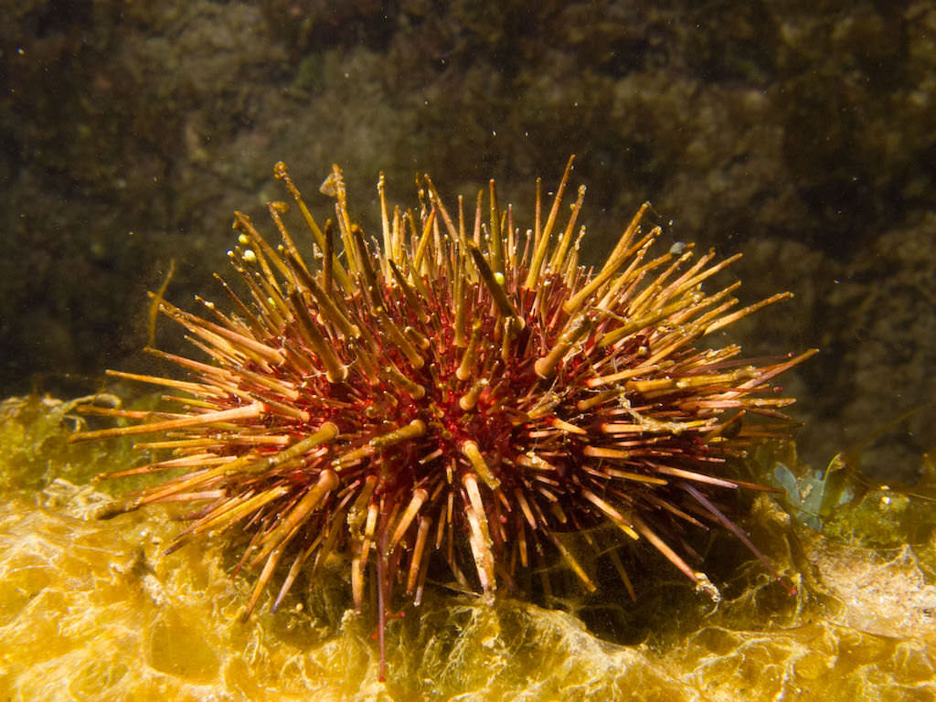

Sea urchin, *Heliocidaris erythrogramma*. Mick Keough, [CC BY 4.0](https://creativecommons.org/licenses/by-sa/4.0)

The paper is [here](https://doi.org/10.1371/journal.pone.0053118)

Schlegel, P., Havenhand, J. N., Gillings, M. R. & Williamson, J. E. (2012). Individual variability in reproductive success determines winners and losers under ocean acidification: a case study with sea urchins. *PLoS One*, 7, e53118.

### Preliminaries

First, load the required packages (afex, car, lattice, lme4, lmerTest, nlme, VCA, Rmisc, MuMin)

Import schlegel data file (schlegel.csv)

```r
schlegel <- read.csv("../data/schlegel.csv")
head(schlegel,10)
```

|  | date | ph | avspeedtot | avspeed15 | motile | indiv |
| --- | --- | --- | --- | --- | --- | --- |
| 1 | 07.02.2011 | 8.1 | 11.760774 | 29.83725 | 0.27 | 1 |
| 2 | 07.02.2011 | 8.1 | 15.807174 | 39.65866 | 0.32 | 1 |
| 3 | 07.02.2011 | 8.1 | 13.201562 | 28.25719 | 0.21 | 1 |
| 4 | 07.02.2011 | 8.1 | 8.625714 | 32.84674 | 0.14 | 1 |
| 5 | 07.02.2011 | 8.1 | 8.120313 | 32.28173 | 0.14 | 1 |
| 6 | 07.02.2011 | 8.1 | 13.486987 | 33.54992 | 0.26 | 1 |
| 7 | 07.02.2011 | 8.1 | 12.766172 | 34.77778 | 0.26 | 1 |
| 8 | 07.02.2011 | 8.1 | 14.124605 | 37.71169 | 0.28 | 1 |
| 9 | 07.02.2011 | 8.1 | 12.077703 | 33.79878 | 0.21 | 1 |
| 10 | 08.02.2011 | 8.1 | 24.982182 | 35.24524 | 0.62 | 2 |

Set contrasts to sum from afex

```r
set_sum_contrasts()
```

```
## setting contr.sum globally: options(contrasts=c('contr.sum', 'contr.poly'))
```

Convert pH and indiv to factors

```r
schlegel$ph <- factor(schlegel$ph)
schlegel$indiv <- factor(schlegel$indiv)
```

### Check assumptions with boxplots

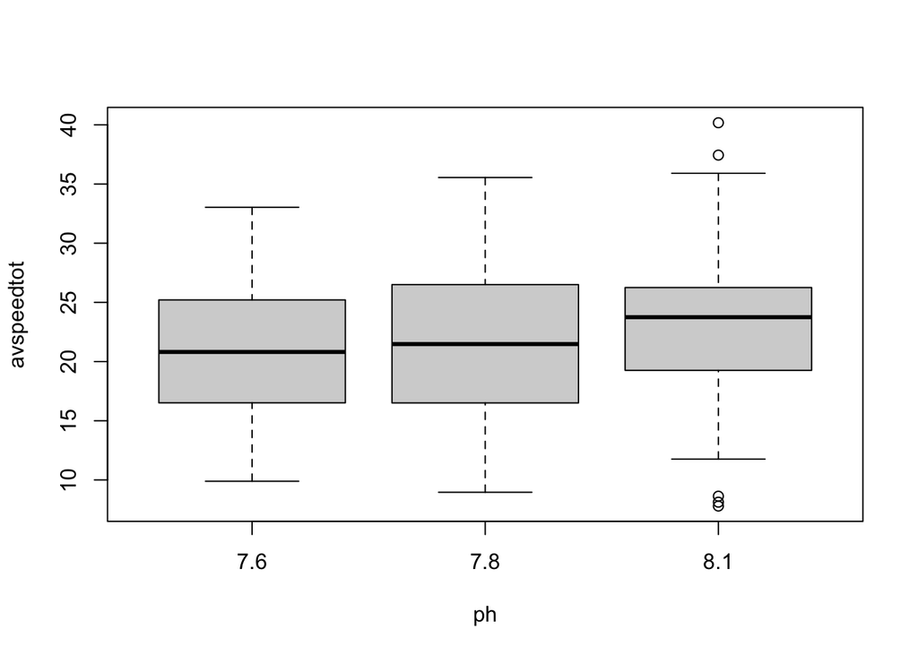

```r
boxplot(avspeedtot~ph, data=schlegel)
```

### Fit model with default aov type I SS

```r
schlegel.aov <- aov(avspeedtot~ph*indiv, data=schlegel)
```

Check residuals - look OK

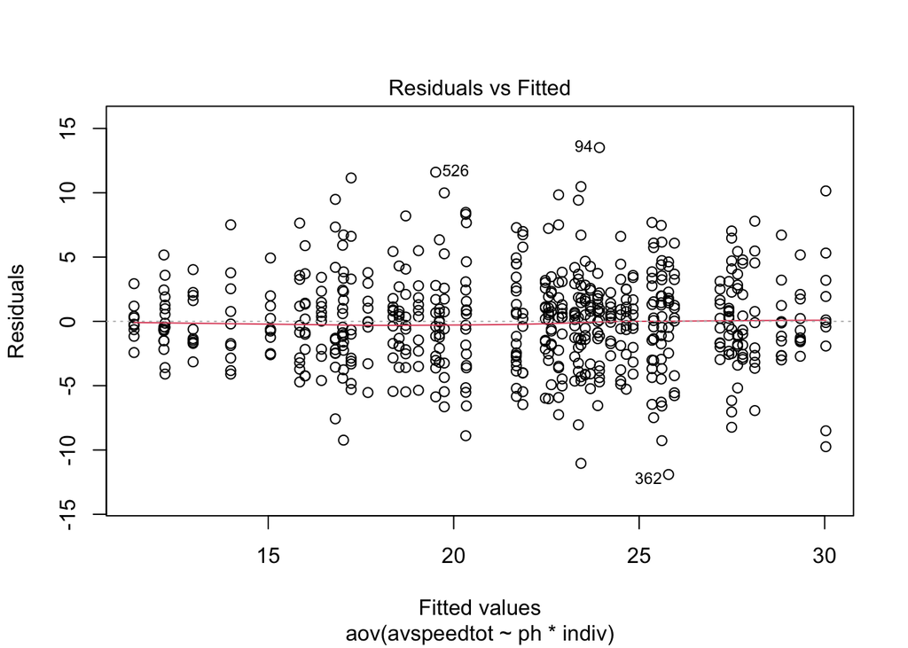

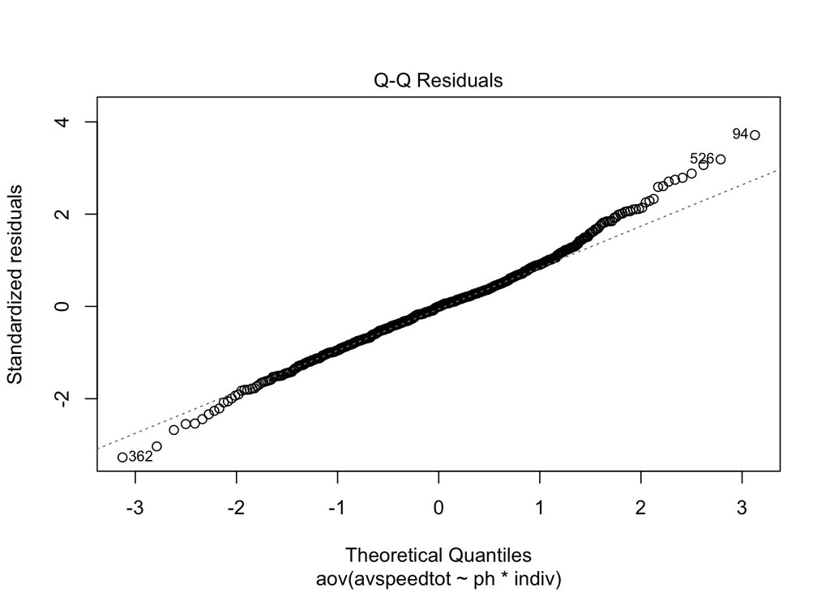

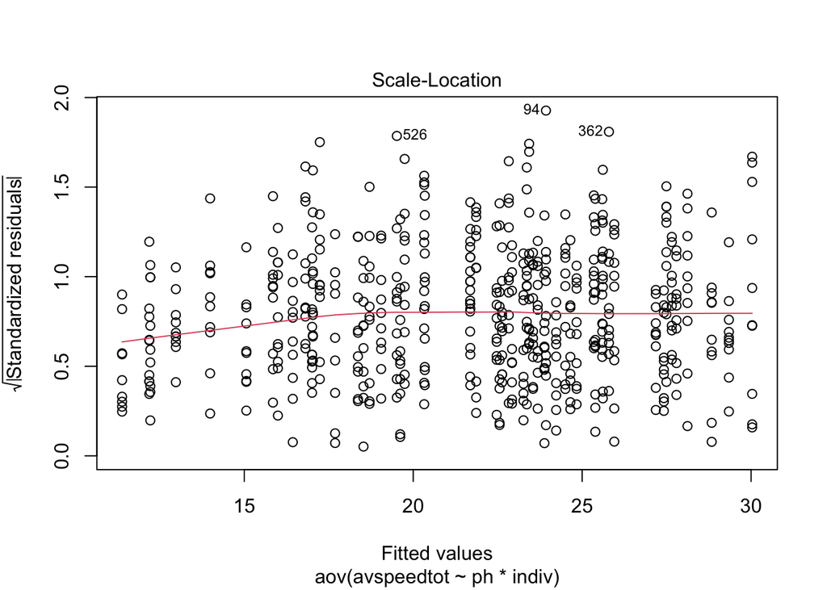

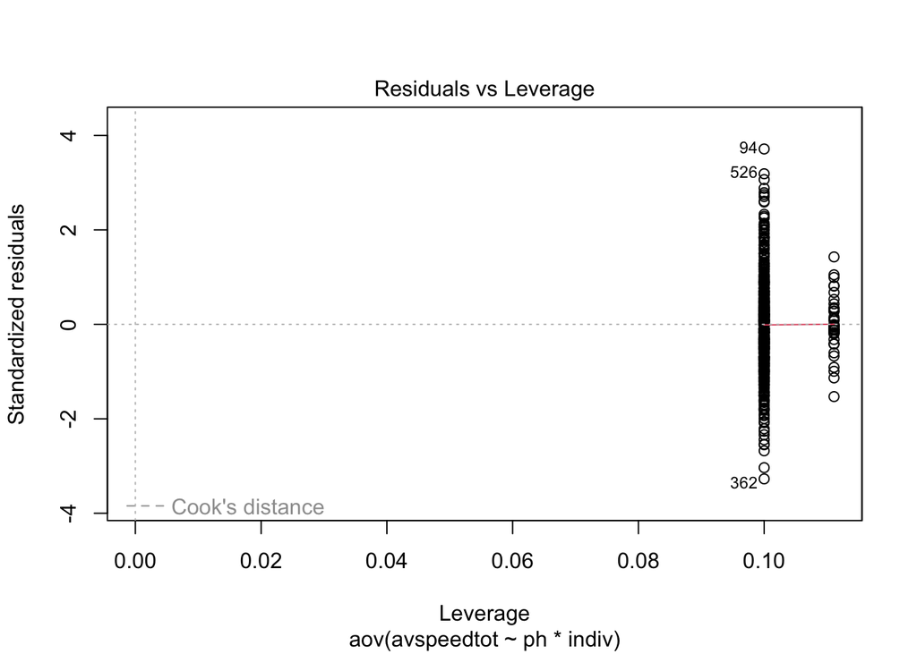

```r
plot(schlegel.aov)
```